# Making Maps Interactive: Building a Shiny Data Visualization App

TIF Lesson 6 in R

Author

Danielle Sass

Published

September 11, 2026

## 1 Overview

In this lesson, we’ll make a simple shiny app that allows us to change a visualization based on a user selection.

### 1.1 Learning Objectives

By the end of this lesson, you should be able to:

- Create a shiny app

### 1.2 Packages Needed

The following packages are needed for this lesson:

```r
library(tidyverse)
library(sf)
library(leaflet)
library(mapview)
library(shiny)
```

## 2 Create App File

Create a shiny app by going to `File -> New File -> Shiny Web App`

Name your file “tif_map_app” and click “Create”.

## 3 Load data and needed packages

We are going to use the data and map from **Lesson 5** in our Shiny App.

**Solution**

```r
library(tidyverse)
library(sf)
library(mapview)
library(shiny)

# load data
tif_data_clean <- read_csv("data/tif_data_clean.csv")

tif_2022 <- tif_data_clean |>
  filter(tif_year == 2022)

# load shape file
sf_2022 <- st_read("tif_boundaries")
sf_2022 <- st_transform(sf_2022, crs = "+proj=longlat +datum=WGS84")
sf_2022 <- sf_2022 |>
  mutate(tif_number = str_remove_all(ref, "[T\\-\\s]") |> as.numeric())

# merge data
tif_map_data <- sf_2022 |>
  inner_join(tif_2022, by = "tif_number")
```

## 4 The Shiny App Interface

### 4.1 Understanding the UI

The UI (user interface) controls what the user sees and interacts with. The app is currently pre-filled with a sample interface and plot. Take a moment to look at the code provided within the `ui <-` assignment.

- `titlePanel()` adds a title to the app
- `sidebarLayout()` organizes the app into two main sections: a sidebar for inputs and a main panel for outputs.
- `sidebarPanel()` creates the sidebar where user inputs and controls are placed.
- `sliderInput()` creates an input control that allows the user to select a value with the slider.
- `mainPanel()` creates the main area where outputs are displayed.
- `plotOutput()` creates a space in the UI where a plot generated by the server will appear.

Click “Run App” to see how each of these components is reflected in the app.

### 4.2 Understanding the Server

The server contains the code that tells the app how to respond to the user inputs and generate outputs such as plots, tables, or other objects.

- `server <- function(input, output)` creates the server function and gives us access to the app’s inputs and outputs.
- `renderPlot()` contains the code used to create a plot that will be displayed in the UI.
- `output$distPlot` connects the plot created by `renderPlot()` to the output named `"distPlot"`.

### 4.3 Communication between the UI and Server

The UI and server communicate using IDs. An ID gives and input or output a name that can be referenced elsewhere in the app.

- In the UI, `plotOutput("distPlot")` creates a space for an output named `"distPlot"`. In the server, `output$distPlot` tells Shiny what should be displayed in that space.
- In the UI, `sliderInput()` is given the ID `"bins"`. In the server, `input$bins` retrieves the value selected by the user.
- When the user changes the slider, Shiny automatically updates `input$bins` and reruns the relevant server code.

This creates the basic Shiny workflow:

**User interacts with the UI → Shiny sends the input to the server → Server generates an output → UI displays the output**

## 5 Modify our map

We will use the interactive map from **Lesson 5**, “Make an Interactive Map,” as the starting point for our Shiny app. We will first replace the sample plot with our map. Later, we will modify the app so the user can choose which variable is displayed.

### 5.1 Update the Output

The sample Shiny app currently creates a plot using `renderPlot({})`. We want to replace this plot with our interactive map.

First, copy the map code from **Lesson 5**, “Make an Interactive Map”.

- Delete ALL of the code inside `renderPlot({})`
- Paste the map code from **Lesson 5** inside `renderPlot({})`

**Solution**

```r
tif_map_data |>
  mapview(
    zcol = "property_tax_extraction",
    layer.name = "Property Tax Extraction"
  )
```

If you try to run the app now, it will not work. This is because `renderPlot({})` is designed to create static plots, while our map is an interactive map.

Shiny provides different `render*()` functions depending on the type of output we want to display. You can learn more about these functions in [Shiny Render Functions](https://shiny.posit.co/r/getstarted/build-an-app/reactive-flow/render-functions.html).

For an interactive map, we use `renderLeaflet({})`.

- In the server, replace `renderPlot` with `renderLeaflet`.
- In the UI, replace `plotOutput()` with its corresponding Leaflet output function.

**Solution**

In the UI:

```r
leafletOutput("distPlot")
```

In the server:

```r
output$distPlot <- renderLeaflet
```

Since our plot is a `mapview` object, we need to extract the `leaflet` object using `@map`. Add `@map` to the end of `mapview()`.

**Solution**

```r
mapview(
        tif_map_data,
        zcol = input$vars,
        layer.name = input$vars
      )@map
```

Now click “Run App”. The app should run successfully with our plot displayed. However, notice that when you change the slider input it does not do anything.

### 5.2 Change widget

The sample Shiny app used the `sliderInput()` to allow the user to change the number of bins on a histogram. Our goal is to allow the user to change the variable displayed in the map. You can learn more about different inputs at [Shiny UI Inputs](https://shiny.posit.co/r/getstarted/build-an-app/reactive-flow/ui-inputs.html).

Look at the different inputs, which one would be most appropriate for our app?

**Solution**

`selectInput` allows us to select different variables

Look up the help documentation by typing `??selectInput` in the console.

- In the UI, replace `sliderInput` with `selectInput`.
  - change the `inputId` to be “vars”
  - change the `label` to be “Variable Displayed”
  - delete the arguments `min`, `max`, and `value` as they are no longer relevant to our function

Let’s create a variable to contain the “choices”. In your app, **before** the UI and **after** you loaded in your packages and data. Create an object named `var_choices`. You could manually type in a vector of variable names from your dataset OR a better option is to use a function such as `colnames` to retrieve the column names from your dataset.

- start with your dataset
- `select` the financial variables
- pipe on the `colnames()` function
- assign this to `var_choices`

**Solution**

```r
var_choices <- tif_2022 |>
  select(property_tax_extraction:finance_costs) |>
  colnames()
```

Now in the UI, within the `selectInput` function set the argument

- `choices = var_choices`

**Run the app**. You should be able to see and interact with the new widget, however it will not change the map.

Now let’s connect the widget to the server.

Within `mapview`, set both `zcol` and `layer.name` equal to `input$vars`. Recall, `vars` is the **ID** assigned to the widget.

Click “Run App” and try switching the variable within the widget. It should now change the variable displayed!

### 5.3 Update the Title

Finally let’s update the title. Within `titlePanel` change the title to an appropriate name.

### 5.4 Your Completed App

**Solution**

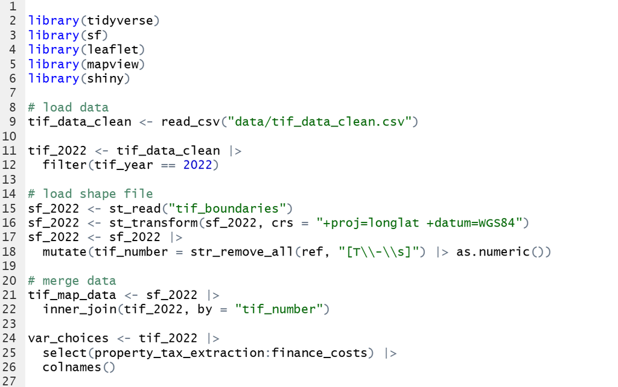

pre-app

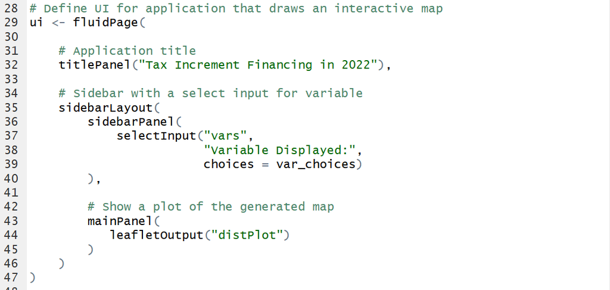

ui

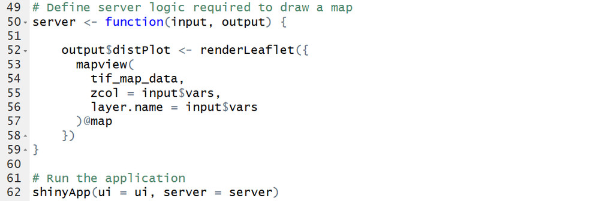

server

[figure not shown]

App

## 6 Challenge

[Mastering Shiny](https://mastering-shiny.org/index.html) is a useful reference for more advanced examples of shiny applications.

To improve the app consider trying one or more of the following tasks:

- add the argument `label` to `selectInput` by creating a vector where the choices are written with spaces instead of underscores and proper capitalization.
- add text to the app that introduces the data.
- add a second widget that allows you to select the `year` to display. Hint: may want to filter on the year and merge shape data within the server instead.
- add a second tab that displays a table of information.